# Functional plant indicators, wetland ecosystems (Moisture, Light, pH, Nitrogen)

*Author and date:* Joachim Töpper

May 2023

| Ecosystem | Økologisk.egenskap | ECT.class |
| --- | --- | --- |
| våtmark | Primærproduksjon | Functional state characteristic |
| våtmark | Abiotiske forhold | Functional state characteristic |

## Introduction

Functional plant indicators can be used to describe the functional signature of plant communities by calculating community-weighted means of plant indicator values for plant communities (Diekmann 2003). The functional signature of plant communities may be indicative of ecosystem identity, depending on which functional plant indicator we look at (cf. Töpper et al. 2018). For instance, using an indicator for moisture one would find a functional signature with higher moisture values for plant communities in mires compared to e.g. grasslands or forests. Deviations in the functional signature of such an indicator beyond a certain range of indicator values (as there of course is natural variation of functional signatures within an ecosystem type) may be related to a reduction in ecological condition. Here, we combine functional plant indicator data with field sampled plant community data from the Norwegian nature monitoring program ANO (Tingstad et al. 2019) for wetland ecosystems. We calculate the functional signature of plant communities in the monitored sites with respect to light, moisture, pH and nitrogen. These functional signatures are then compared to reference distributions of functional signature, separately for each wetland ecosystem type, calculated from ‘generalized species lists’ underlying the Norwegian categorization system for eco-diversity (Halvorsen et al. 2020). These plant functional condition indicators are developed following the principles and technical protocol of the IBECA framework (Jakobsson et al. 2021, Töpper & Jakobsson 2021). Note that deviations from the reference may occur in both directions, e.g. the moisture signature from the testing data may be higher or lower than in the reference. Deviations in these two directions indicate very different environmental phenomena and thus have to be treated separately. Therefore, we develop two condition indicators for each functional plant indicator, a lower one and an upper one (see further down for more details).

## About the underlying data

In the ‘functional plant indicator’ project for wetlands, we use three sets of data for building indicators for ecological condition:

- as test data we use plant community data from the ANO monitoring scheme (cf. Tingstad et al. 2019)
- as reference data we use generalized species lists from the Norwegian categorization system for eco-diversity (NiN) (cf. Halvorsen et al. 2020)
- Swedish plant indicator data for light, moisture, pH, and nitrogen from Tyler et al. (2021)
1. ANO monitoring data: ANO stands for ‘areal-representativ naturovervåking’, i.e. ‘area representative nature monitoring’. 1000 sites are randomly distributed across mainland Norway and visited within a 5-year cycle. Each ANO site spans a 500 x 500 m grid cell, and the data collection at each ANO site includes up to 12 evenly distributed vegetation analyses in 1 x 1 m plots (up to 12, because some of these evenly distributed points may be in water or otherwise inaccessible). For the vegetation analyses, the cover of each vascular plant species in the plot is recorded. Every vegetation analysis is accompanied by an assessment of the ecosystem the plot lies in, including ecosystem type and some additional variables related to ecosystem-specific drivers of state. In the wetland-analysis in this document, we only use the plots which were classified as one of the wetland ecosystem types in the Norwegian categorization system for eco-diversity (NiN). In the analysis in this document, we use the data available on Miljødirektoratets kartkatalog (https://kartkatalog.miljodirektoratet.no/Dataset/Details/2054), which comprises data from the first three ANO-years, 2019-2021, and a total of 8887 plots in 498 sites.
2. NiN reference data: The generalized species lists underlying the ecosystem categorization in NiN represent expert-compiled species lists based on empirical evidence from the literature and expert knowledge of the systems and their species. In these lists, every species is assigned an abundance value on a 6-step scale, with each step representing a range for the ‘expected combination of frequency and cover’ of occurrence (1: < 1/32, 2: 1/32 - 1/8 , 3: 1/8 - 3/8, 4: 3/8 - 4/5, 5: 3/8 - 4/5 + dominance, 6: > 4/5). For the purpose of this project, these steps are simplified to maximum ‘expected combination of frequency and cover’, whereby steps 4 & 5 are assigned 0.6 and 0.8, respectively, in order to distinguish between them.
3. The Swedish plant indicator set published by Tyler et al. (2021) contains a large collection of plant indicators based on the Swedish flora, which is well representative of the Norwegian flora as well. From this set, we decided to include indicator data for light, moisture, pH, and nitrogen for wetlands as these are thought to be subject to potential change due to shrub/tree encroachment, drainage, and pollution.

### Representativity in time and space

For wetlands, the ANO data contain 1351 plots in 330 sites, in principle distributed randomly across the country. As wetlands occur more often in certain regions of Norway than in others, the amount of plots and sites is not equal among Norway’s five regions. The 1351 plots are distributed across regions in the following way:

- Northern Norway: 416
- Central Norway: 362
- Eastern Norway: 295
- Western Norway: 151
- Southern Norway: 127

### Temporal coverage

The evaluation data cover the first three years, 2019-2021, of the first 5-year-cycle in the ANO monitoring scheme. Thus there is no actual time series to these data, and the indicator evaluation does therefore not include any temporal analyses.

## Collinearities with other indicators

## Reference state and values

### Reference state

The reference state is defined via the functional signature of the generalized species lists in NiN (see also Töpper et al. 2018). By bootstrapping the species lists (see details further below) and calculating community-weighted means of functional plant indicators for every re-sampled community, we describe the reference state as a distribution of indicator values for each respective plant functional indicator. These distributions are calculated for ecosystem sub-types (“grunntyper” or “kartleggingsenheter” at a 1:5000 mapping scale) within the main wetland types in NiN. A more extensive discussion on the use of reference communities can be found in Jakobsson et al. (2020).

### Reference values, thresholds for defining *good ecological condition*, minimum and/or maximum values

In this analysis, we derive scaling values from statistical (here, non-parametric) distributions (see Jakobsson et al. 2010). For each ecosystem sub-type and plant functional indicator, the reference value is defined as the median value of the indicator value distribution. As in most cases the distributions naturally are two-sided (but see the Heat-requirement indicator in the mountain assessment for an example of a one-sided functional plant indicator, Fremstad et al. 2022), and deviation from the optimal state thus may occur in both direction (e.g. indicating too low or too high pH), we need to define two threshold values for good ecological condition as well as both a minimum and maximum value. In line with previous assessments of ecological condition for Norwegian forests and mountains, we define a lower and an upper threshold value via the 95% confidence interval of the reference distribution, i.e. its 0.025 and 0.975 quantiles. The minimum and maximum values are given by the minimum and maximum of the possible indicator values for each respective plant functional indicator. For details on the scaling principles in IBECA, please see Töpper & Jakobsson (2021).

## Uncertainties

We can calculate a mean indicator value (after scaling) for every region (or any other delimited area of interest) as well as its corresponding standard error and standard deviation as a measure of spatial uncertainty for a geographical area.

## References

Diekmann, M. 2003. Species indicator values as an important tool in applied plant ecology - a review. Basic and Applied Ecology 4: 493-506, doi:10.1078/1439-1791-00185

Framstad, E., Kolstad, A. L., Nybø, S., Töpper, J. & Vandvik, V. 2022. The condition of forest and mountain ecosystems in Norway. Assessment by the IBECA method. NINA Report 2100. Norwegian Institute for Nature Research.

Halvorsen, R., Skarpaas, O., Bryn, A., Bratli, H., Erikstad, L., Simensen, T., & Lieungh, E. (2020). Towards a systematics of ecodiversity: The EcoSyst framework. Global Ecology and Biogeography, 29(11), 1887-1906. doi:10.1111/geb.13164

Jakobsson, S., Töpper, J.P., Evju, M., Framstad, E., Lyngstad, A., Pedersen, B., Sickel, H., Sverdrup-Thygeson, A., Vandvik. V., Velle, L.G., Aarrestad, P.A. & Nybø, S. 2020. Setting reference levels and limits for good ecological condition in terrestrial ecosystems. Insights from a case study based on the IBECA approach. Ecological Indicators 116: 106492.

Jakobsson, S., Evju, M., Framstad, E., Imbert, A., Lyngstad, A., Sickel, H., Sverdrup-Thygeson, A., Töpper, J., Vandvik, V., Velle, L.G., Aarrestad, P.A. & Nybø, S. 2021. An index-based assessment of ecological condition and its links to international frameworks. Ecological Indicators 124: 107252.

Tingstad, L., Evju, M., Sickel, H., & Töpper, J. 2019. Utvikling av nasjonal arealrepresentativ naturovervåking (ANO). Forslag til gjennomføring, protokoller og kostnadsvurderinger med utgangspunkt i erfaringer fra uttesting i Trøndelag. NINA Rapport 1642.

Töpper, J. & Jakobsson, S. 2021. The Index-Based Ecological Condition Assessment (IBECA) - Technical protocol, version 1.0. NINA Report 1967. Norwegian Institute for Nature Research.

Töpper, J., Velle, L.G. & Vandvik, V. 2018. Developing a method for assessment of ecological state based on indicator values after Ellenberg and Grime (revised edition). NINA Report 1529b. Norwegian Institute for Nature Research.

Tyler, T., Herbertsson, L., Olofsson, J., & Olsson, P. A. 2021. Ecological indicator and traits values for Swedish vascular plants. Ecological In-dicators, 120. doi:10.1016/j.ecolind.2020.106923

## Analyses

### Data sets

ANO data

Plant indicators from Tyler et al. (2021)

Generalized species lists NiN

#### Data handling

- Checking for errors
- Checking species nomenclature in the different species lists to make species and indicator data possible to merge
- Merging indicator data with monitoring data and indicator data with reference data (not shown here, but documented in the code)

leaving us with the monitoring data including plant indicators (ANO.sp.ind) and the reference data including plant indicators (NiN.wetland.cov)

```r
head(ANO.sp.ind)
```

```
##      Species art_dekning                         ParentGlobalID Light Moisture Soil_reaction_pH
## 1 Abies alba           0 {CB1796B9-01F5-4109-B44E-4582CA855F93}     2        5                5
## 2 Abies alba           0 {AB9ED5C2-E906-4C73-B543-EC6CB28B39D5}     2        5                5
## 3 Abies alba           0 {32A9B462-5483-4D47-ADAF-78F11AF201AA}     2        5                5
## 4 Abies alba           0 {004C000D-459B-4244-96F4-4FF8B06454D4}     2        5                5
## 5 Abies alba           0 {B7DD61EE-A113-4486-A4B8-D50ACAAC648B}     2        5                5
## 6 Abies alba           0 {0431743B-F268-4819-98F7-FFB7006E55BA}     2        5                5
##   Nitrogen
## 1        5
## 2        5
## 3        5
## 4        5
## 5        5
## 6        5
```

```r
head(NiN.wetland.cov)
```

```
##                        sp V3-C1a V3-C1b V3-C1c V3-C1d V3-C1e V1-C1a V1-C1b V1-C1c V1-C1d V1-C1e V1-C2a
## 1    Abietinella abietina      0      0      0      0      0      0      0      0      0      0      0
## 2        Acer platanoides      0      0      0      0      0      0      0      0      0      0      0
## 3    Achillea millefolium      0      0      0      0      0      0      0      0      0      0      0
## 4       Achillea ptarmica      0      0      0      0      0      0      0      0      0      0      0
## 5         Acinos arvensis      0      0      0      0      0      0      0      0      0      0      0
## 6 Aconitum septentrionale      0      0      0      0      0      0      0      0      0      0      0
##   V1-C2b V1-C2c V1-C2d V1-C3a V1-C3b V1-C3c V1-C3d V1-C4a V1-C4b V1-C4c V1-C4d V1-C4e V1-C4f V1-C4g
## 1      0      0      0      0      0      0      0      0      0      0      0      0      0      0
## 2      0      0      0      0      0      0      0      0      0      0      0      0      0      0
## 3      0      0      0      0      0      0      0      0      0      0      0      0      0      0
## 4      0      0      0      0      0      0      0      0      0      0      0      0      0      0
## 5      0      0      0      0      0      0      0      0      0      0      0      0      0      0
## 6      0      0      0      0      0      0      0      0      0      0      0      0      0      0
##   V1-C4h V3-C2 V1-C5 V1-C6a V1-C6b V1-C7a V1-C7b V1-C8a V1-C8b V2-C1a V2-C1b V2-C2a V2-C2b V2-C3a
## 1      0     0     0      0      0      0      0      0      0      0      0      0      0      0
## 2      0     0     0      0      0      0      0      0      0      0      0      0      0      0
## 3      0     0     0      0      0      0      0      0      0      0      0      0      0      0
## 4      0     0     0      0      0      0      0      0      0      0      0      0      0      0
## 5      0     0     0      0      0      0      0      0      0      0      0      0      0      0
## 6      0     0     0      0      0      0      0      0      0      0      0      0      0      0
##   V2-C3b V4-C2 V4-C3 V8-C1 V8-C2 V8-C3 Light Moisture Soil_reaction_pH Nitrogen
## 1      0     0     0     0     0     0    NA       NA               NA       NA
## 2      0     0     0     0     0     0     4        4                6        5
## 3      0     0     0     0     0     0     6        2                5        5
## 4      0     0     0     0     0     0     5        6                4        4
## 5      0     0     0     0     0     0     7        1                7        3
## 6      0     0     0     0     0     0     4        5                7        7
```

For each ecosystem type with a NiN species list, we can calculate a community weighted mean (CWM) for the relevant functional plant indicators. For wetland ecosystem we are testing “Light”, “Moisture”, “Soil_reaction_pH”, and “Nitrogen”. In order to get distributions of CWMs rather than one single value (for comparison with the empirical testing data) the NiN lists can be bootstrapped.

##### bootstrap function for frequency abundance

- function to calculate community weighted means of selected indicator values (ind)
- for species lists (sp) with given abundances in percent (or on a scale from 0 to 1) in one or more ‘sites’ (abun)
- with a given number of iterations (iter),
- with species given a certain minimum abundance occurring in all bootstraps (obl), and
- with a given re-sampling ratio of the original species list (rat)
- in every bootstrap iteration the abundance of the sampled species can be randomly changed by a limited amount if wished by introducing a re-sampling of abundance values from adjacent abundance steps with a certain probability (var.abun)

Running the bootstraps

```r
colnames(NiN.wetland)
# 1st column is the species
# 2nd-46th column is the abundances of sp in different ecosystem types
# 47th-50th column is the indicator values of the respective species
# we choose 1000 iterations
# species with abundance 1 (i.e. a max of 100%, must be included in each sample)
# each sample re-samples 1/3 of the number of species
# the abundance of the re-sampled species may vary (see bootstrap function for details)
wetland.ref.cov <- indBoot.freq(sp=NiN.wetland.cov[,1],abun=NiN.wetland.cov[,2:46],ind=NiN.wetland.cov[,47:50],
                          iter=1000,obl=1,rat=1/3,var.abun=T)

# fixing NaNs
for (i in 1:length(wetland.ref.cov) ) {
  for (j in 1:ncol(wetland.ref.cov[[i]]) ) {
    v <- wetland.ref.cov[[i]][,j]
    v[is.nan(v)] <- NA
    wetland.ref.cov[[i]][,j] <- v
  }
}
```

```r
head(wetland.ref.cov[[1]])
```

```
##   V3-C1a   V3-C1b   V3-C1c   V3-C1d   V3-C1e   V1-C1a   V1-C1b   V1-C1c   V1-C1d   V1-C1e   V1-C2a
## 1     NA 5.537118 5.519421 4.516616 5.198992 5.615385 5.665025 5.040943 5.444206 5.284579 4.516291
## 2     NA 5.545455 5.303867 5.500000 4.984615 4.857143 5.025050 5.823529 5.087358 5.187335 5.649860
## 3     NA 6.588832 5.376543 5.904977 4.833333 5.972973 6.312500 5.710956 5.576603 5.154487 5.781485
## 4     NA 6.308017 5.042328 5.298507 5.245614 4.526066 5.564772 5.372824 5.022936 5.016098 6.454976
## 5     NA 5.761421 5.333333 5.822622 5.010862 5.758621 5.471328 6.035370 5.608986 4.988055 6.576869
## 6     NA 5.300000 5.672269 5.250000 5.076159 6.250000 5.390782 4.984520 4.877800 4.603080 4.896975
##     V1-C2b   V1-C2c   V1-C2d   V1-C3a   V1-C3b   V1-C3c   V1-C3d   V1-C4a   V1-C4b   V1-C4c   V1-C4d
## 1 5.500000 4.727120 5.234536 6.242694 5.292952 5.109108 5.214753 5.674512 6.100610 5.916846 6.220841
## 2 6.029586 5.256491 5.175023 6.561584 5.814873 6.167920 5.461832 6.421354 5.719110 5.691259 5.397706
## 3 6.008580 5.631367 5.672697 4.837065 5.289557 5.324456 4.809302 5.486574 6.149593 5.485597 5.446296
## 4 4.520129 5.417409 5.424689 6.581006 4.581459 5.104036 5.271104 5.870466 5.936061 5.465432 6.407635
## 5 5.655134 5.715929 5.782609 5.982505 5.684211 5.732940 5.369686 6.063272 5.979097 5.489074 5.492537
## 6 6.073020 4.876417 4.808176 5.975198 5.335248 5.198312 5.698343 6.338515 6.172363 5.180462 5.120773
##     V1-C4e   V1-C4f   V1-C4g   V1-C4h    V3-C2    V1-C5   V1-C6a   V1-C6b   V1-C7a   V1-C7b   V1-C8a
```

[output cut: 20 more lines]

This results in an R-list with a slot for every selected indicator, and in every slot there’s a data frame with as many columns as there are NiN species lists and as many rows as there were iterations in the bootstrap. Next, we need to derive scaling values from these bootstrap-lists (the columns) for every mapping unit in NiN. Here, we define things in the following way:

- Median = reference values
- 0.025 and 0.975 quantiles = lower and upper limit values
- min and max of the respective indicator’s scale = min/max values

```
##   V3-C1a   V3-C1b   V3-C1c   V3-C1d   V3-C1e   V1-C1a   V1-C1b   V1-C1c   V1-C1d   V1-C1e   V1-C2a
## 1     NA 5.537118 5.519421 4.516616 5.198992 5.615385 5.665025 5.040943 5.444206 5.284579 4.516291
## 2     NA 5.545455 5.303867 5.500000 4.984615 4.857143 5.025050 5.823529 5.087358 5.187335 5.649860
## 3     NA 6.588832 5.376543 5.904977 4.833333 5.972973 6.312500 5.710956 5.576603 5.154487 5.781485
## 4     NA 6.308017 5.042328 5.298507 5.245614 4.526066 5.564772 5.372824 5.022936 5.016098 6.454976
## 5     NA 5.761421 5.333333 5.822622 5.010862 5.758621 5.471328 6.035370 5.608986 4.988055 6.576869
## 6     NA 5.300000 5.672269 5.250000 5.076159 6.250000 5.390782 4.984520 4.877800 4.603080 4.896975
##     V1-C2b   V1-C2c   V1-C2d   V1-C3a   V1-C3b   V1-C3c   V1-C3d   V1-C4a   V1-C4b   V1-C4c   V1-C4d
## 1 5.500000 4.727120 5.234536 6.242694 5.292952 5.109108 5.214753 5.674512 6.100610 5.916846 6.220841
## 2 6.029586 5.256491 5.175023 6.561584 5.814873 6.167920 5.461832 6.421354 5.719110 5.691259 5.397706
## 3 6.008580 5.631367 5.672697 4.837065 5.289557 5.324456 4.809302 5.486574 6.149593 5.485597 5.446296
## 4 4.520129 5.417409 5.424689 6.581006 4.581459 5.104036 5.271104 5.870466 5.936061 5.465432 6.407635
## 5 5.655134 5.715929 5.782609 5.982505 5.684211 5.732940 5.369686 6.063272 5.979097 5.489074 5.492537
## 6 6.073020 4.876417 4.808176 5.975198 5.335248 5.198312 5.698343 6.338515 6.172363 5.180462 5.120773
##     V1-C4e   V1-C4f   V1-C4g   V1-C4h    V3-C2    V1-C5   V1-C6a   V1-C6b   V1-C7a   V1-C7b   V1-C8a
```

[output cut: 20 more lines]

```
##  [1] V3-C1a V3-C1b V3-C1c V3-C1d V3-C1e V1-C1a V1-C1b V1-C1c V1-C1d V1-C1e V1-C2a V1-C2b V1-C2c V1-C2d
## [15] V1-C3a V1-C3b V1-C3c V1-C3d V1-C4a V1-C4b V1-C4c V1-C4d V1-C4e V1-C4f V1-C4g V1-C4h V3-C2  V1-C5
## [29] V1-C6a V1-C6b V1-C7a V1-C7b V1-C8a V1-C8b V2-C1a V2-C1b V2-C2a V2-C2b V2-C3a V2-C3b V4-C2  V4-C3
## [43] V8-C1  V8-C2  V8-C3
## <0 rows> (or 0-length row.names)
```

```
##  [1] "V3-C1" "V1-C1" "V1-C2" "V1-C3" "V1-C4" "V3-C2" "V1-C5" "V1-C6" "V1-C7" "V1-C8" "V2-C1" "V2-C2"
## [13] "V2-C3" "V4-C2" "V4-C3" "V8-C1" "V8-C2" "V8-C3"
```

```
##  [1] "V3-C1a" "V3-C1b" "V3-C1c" "V3-C1d" "V3-C1e" "V1-C1a" "V1-C1b" "V1-C1c" "V1-C1d" "V1-C1e" "V1-C2a"
## [12] "V1-C2b" "V1-C2c" "V1-C2d" "V1-C3a" "V1-C3b" "V1-C3c" "V1-C3d" "V1-C4a" "V1-C4b" "V1-C4c" "V1-C4d"
## [23] "V1-C4e" "V1-C4f" "V1-C4g" "V1-C4h" "V3-C2"  "V1-C5"  "V1-C6a" "V1-C6b" "V1-C7a" "V1-C7b" "V1-C8a"
## [34] "V1-C8b" "V2-C1a" "V2-C1b" "V2-C2a" "V2-C2b" "V2-C3a" "V2-C3b" "V4-C2"  "V4-C3"  "V8-C1"  "V8-C2"
## [45] "V8-C3"
```

```
##  [1] "V3-C1" "V1-C1" "V1-C2" "V1-C3" "V1-C4" "V1-C6" "V1-C7" "V1-C8" "V2-C1" "V2-C2" "V2-C3"
```

```
## [1] 1 2 3 4 5
```

```
##          V1       V2       V3       V4       V5       V6       V7       V8       V9      V10      V11
## 1  4.650288 4.966443 5.242167 4.730467 5.450611 6.287387 1.655954 2.069755 2.814447 1.798326 2.101967
## 2  4.412518 4.678375 4.983052 5.024660 5.705182 6.515412 1.858930 2.328319 2.983125 1.707630 2.083033
## 3  4.181051 4.885976 5.575828 5.959727 7.108910 7.929956 3.022003 3.802753 4.769512 2.638866 3.345274
## 4  4.265677 4.970310 5.728271 6.072307 6.944127 7.598114 3.495213 4.389075 5.344473 2.841443 3.687148
## 5  4.026841 4.715468 5.326302 6.041072 7.262666 8.132334 3.322124 4.182404 4.879182 3.634319 4.453431
## 6  4.331418 4.760871 5.131781 6.519606 7.245583 7.905369 4.279028 4.750092 5.202615 4.680611 5.400094
## 7  4.379654 4.687800 4.977008 6.665973 7.502367 8.189600 4.502166 4.913133 5.280336 5.067941 5.752526
## 8  4.676349 5.342796 6.777778 4.473684 6.424165 8.467209 1.082218 1.951116 3.292487 1.006211 1.544669
## 9  4.735842 5.388481 6.835764 4.805905 6.985401 9.142989 1.304445 1.971098 4.000000 1.049953 1.613392
## 10 4.684189 5.548379 6.753948 5.703439 7.826415 9.337017 1.623551 2.737952 4.376870 1.202420 1.908494
## 11 4.644572 5.484308 6.487499 6.503395 8.213247 9.445956 2.307563 3.592224 4.848489 1.360667 2.344593
## 12 4.552329 5.686564 6.494601 6.530966 8.109657 9.294677 2.929122 4.566270 5.959868 1.712485 2.626977
## 13 4.219840 4.779976 5.423544 5.518264 7.313205 9.248771 2.201466 3.168781 4.330514 2.067017 2.802510
## 14 4.166529 4.692662 5.433001 5.869488 7.241861 8.685496 2.663268 3.405840 4.365503 2.368457 3.072115
```

[output cut: 23 more lines]

```
##      V1   V2   V3   V4   V5   V6   V7   V8   V9  V10  V11  V12
## 1  4.65 4.97 5.24 4.73 5.45 6.29 1.66 2.07 2.81 1.80 2.10 2.49
## 2  4.41 4.68 4.98 5.02 5.71 6.52 1.86 2.33 2.98 1.71 2.08 2.68
## 3  4.18 4.89 5.58 5.96 7.11 7.93 3.02 3.80 4.77 2.64 3.35 4.19
## 4  4.27 4.97 5.73 6.07 6.94 7.60 3.50 4.39 5.34 2.84 3.69 5.21
## 5  4.03 4.72 5.33 6.04 7.26 8.13 3.32 4.18 4.88 3.63 4.45 5.31
## 6  4.33 4.76 5.13 6.52 7.25 7.91 4.28 4.75 5.20 4.68 5.40 6.10
## 7  4.38 4.69 4.98 6.67 7.50 8.19 4.50 4.91 5.28 5.07 5.75 6.27
## 8  4.68 5.34 6.78 4.47 6.42 8.47 1.08 1.95 3.29 1.01 1.54 2.20
## 9  4.74 5.39 6.84 4.81 6.99 9.14 1.30 1.97 4.00 1.05 1.61 2.54
## 10 4.68 5.55 6.75 5.70 7.83 9.34 1.62 2.74 4.38 1.20 1.91 3.14
## 11 4.64 5.48 6.49 6.50 8.21 9.45 2.31 3.59 4.85 1.36 2.34 3.84
## 12 4.55 5.69 6.49 6.53 8.11 9.29 2.93 4.57 5.96 1.71 2.63 3.95
## 13 4.22 4.78 5.42 5.52 7.31 9.25 2.20 3.17 4.33 2.07 2.80 3.66
## 14 4.17 4.69 5.43 5.87 7.24 8.69 2.66 3.41 4.37 2.37 3.07 3.88
## 15 4.21 4.89 5.76 5.71 7.09 8.10 3.27 4.28 5.37 2.55 3.52 4.78
## 16 3.66 4.23 4.95 4.85 5.75 8.80 2.39 2.85 4.13 2.48 3.08 4.16
## 17 3.45 4.24 4.94 5.14 6.47 8.29 2.93 3.63 4.48 3.22 4.10 5.00
## 18 3.24 4.12 4.74 5.56 6.81 8.22 3.33 4.11 4.84 3.95 4.89 5.90
```

```
##    Light_q2.5      Light_q50      Light_q97.5      Moist_q2.5      Moist_q50      Moist_q97.5
##  Min.   :3.242   Min.   :4.122   Min.   :4.739   Min.   :4.474   Min.   :5.451   Min.   :6.287
##  1st Qu.:4.170   1st Qu.:4.689   1st Qu.:5.020   1st Qu.:5.054   1st Qu.:6.559   1st Qu.:7.972
##  Median :4.299   Median :4.833   Median :5.428   Median :5.708   Median :7.097   Median :8.252
##  Mean   :4.249   Mean   :4.893   Mean   :5.642   Mean   :5.649   Mean   :6.970   Mean   :8.310
##  3rd Qu.:4.622   3rd Qu.:5.250   3rd Qu.:6.305   3rd Qu.:6.064   3rd Qu.:7.301   3rd Qu.:9.057
##  Max.   :4.736   Max.   :5.687   Max.   :6.836   Max.   :6.666   Max.   :8.213   Max.   :9.446
##     pH_q2.5          pH_q50         pH_q97.5     Nitrogen_q2.5    Nitrogen_q50   Nitrogen_q97.5
##  Min.   :1.082   Min.   :1.951   Min.   :2.814   Min.   :1.006   Min.   :1.545   Min.   :2.200
##  1st Qu.:1.945   1st Qu.:2.766   1st Qu.:4.183   1st Qu.:1.709   1st Qu.:2.163   1st Qu.:3.268
##  Median :2.795   Median :3.609   Median :4.624   Median :2.426   Median :3.075   Median :4.053
##  Mean   :2.675   Mean   :3.483   Mean   :4.515   Mean   :2.519   Mean   :3.240   Mean   :4.183
##  3rd Qu.:3.308   3rd Qu.:4.254   3rd Qu.:5.122   3rd Qu.:3.127   3rd Qu.:3.994   3rd Qu.:5.157
##  Max.   :4.502   Max.   :4.913   Max.   :5.960   Max.   :5.068   Max.   :5.753   Max.   :6.270
##      NiN
##  Length:18
##  Class :character
##  Mode  :character
##
##
##
```

```
##    Light_q2.5 Light_q50 Light_q97.5 Moist_q2.5 Moist_q50 Moist_q97.5  pH_q2.5   pH_q50 pH_q97.5
## 1    4.650288  4.966443    5.242167   4.730467  5.450611    6.287387 1.655954 2.069755 2.814447
## 2    4.412518  4.678375    4.983052   5.024660  5.705182    6.515412 1.858930 2.328319 2.983125
## 3    4.181051  4.885976    5.575828   5.959727  7.108910    7.929956 3.022003 3.802753 4.769512
## 4    4.265677  4.970310    5.728271   6.072307  6.944127    7.598114 3.495213 4.389075 5.344473
## 5    4.026841  4.715468    5.326302   6.041072  7.262666    8.132334 3.322124 4.182404 4.879182
## 6    4.331418  4.760871    5.131781   6.519606  7.245583    7.905369 4.279028 4.750092 5.202615
## 7    4.379654  4.687800    4.977008   6.665973  7.502367    8.189600 4.502166 4.913133 5.280336
## 8    4.676349  5.342796    6.777778   4.473684  6.424165    8.467209 1.082218 1.951116 3.292487
## 9    4.735842  5.388481    6.835764   4.805905  6.985401    9.142989 1.304445 1.971098 4.000000
## 10   4.684189  5.548379    6.753948   5.703439  7.826415    9.337017 1.623551 2.737952 4.376870
## 11   4.644572  5.484308    6.487499   6.503395  8.213247    9.445956 2.307563 3.592224 4.848489
## 12   4.552329  5.686564    6.494601   6.530966  8.109657    9.294677 2.929122 4.566270 5.959868
## 13   4.219840  4.779976    5.423544   5.518264  7.313205    9.248771 2.201466 3.168781 4.330514
## 14   4.166529  4.692662    5.433001   5.869488  7.241861    8.685496 2.663268 3.405840 4.365503
```

[output cut: 23 more lines]

```
##          N1 hoved  grunn county region       Ind       Rv       Gv maxmin
## 1   wetland    NA V3-C-2    all    all    Light1 4.966443 4.650288      1
## 2   wetland    NA V3-C-2    all    all    Light2 4.966443 5.242167      7
## 3   wetland    NA V1-C-5    all    all    Light1 4.678375 4.412518      1
## 4   wetland    NA V1-C-5    all    all    Light2 4.678375 4.983052      7
## 5   wetland    NA V4-C-2    all    all    Light1 4.885976 4.181051      1
## 6   wetland    NA V4-C-2    all    all    Light2 4.885976 5.575828      7
## 7   wetland    NA V4-C-3    all    all    Light1 4.970310 4.265677      1
## 8   wetland    NA V4-C-3    all    all    Light2 4.970310 5.728271      7
## 9   wetland    NA V8-C-1    all    all    Light1 4.715468 4.026841      1
## 10  wetland    NA V8-C-1    all    all    Light2 4.715468 5.326302      7
## 11  wetland    NA V8-C-2    all    all    Light1 4.760871 4.331418      1
## 12  wetland    NA V8-C-2    all    all    Light2 4.760871 5.131781      7
## 13  wetland    NA V8-C-3    all    all    Light1 4.687800 4.379654      1
## 14  wetland    NA V8-C-3    all    all    Light2 4.687800 4.977008      7
```

[output cut: 98 more lines]

```
##       N1               hoved               grunn       county             region
##  Length:144         Length:144         V1-C-1 : 8   Length:144         Length:144
##  Class :character   Class :character   V1-C-2 : 8   Class :character   Class :character
##  Mode  :character   Mode  :character   V1-C-3 : 8   Mode  :character   Mode  :character
##                                        V1-C-4 : 8
##                                        V1-C-5 : 8
##                                        V1-C-6 : 8
##                                        (Other):96
##         Ind           Rv              Gv            maxmin
##  Light1   :18   Min.   :1.545   Min.   :1.006   Min.   : 1.00
##  Light2   :18   1st Qu.:3.391   1st Qu.:3.315   1st Qu.: 1.00
##  Moist1   :18   Median :4.690   Median :4.682   Median : 4.00
##  Moist2   :18   Mean   :4.646   Mean   :4.718   Mean   : 5.00
##  Nitrogen1:18   3rd Qu.:5.691   3rd Qu.:5.736   3rd Qu.: 8.25
##  Nitrogen2:18   Max.   :8.213   Max.   :9.446   Max.   :12.00
##  (Other)  :36
```

```r
head(wetland.ref.cov.val)
```

```
##        N1 hoved  grunn county region    Ind       Rv       Gv maxmin
## 1 wetland    NA V3-C-2    all    all Light1 4.966443 4.650288      1
## 2 wetland    NA V3-C-2    all    all Light2 4.966443 5.242167      7
## 3 wetland    NA V1-C-5    all    all Light1 4.678375 4.412518      1
## 4 wetland    NA V1-C-5    all    all Light2 4.678375 4.983052      7
## 5 wetland    NA V4-C-2    all    all Light1 4.885976 4.181051      1
## 6 wetland    NA V4-C-2    all    all Light2 4.885976 5.575828      7
```

Once test data (ANO) and the scaling values from the reference data (NiN) are in place, we can calculate CWMs of the selected indicators for the ANO community data and scale them against the scaling values from the reference distribution. Note that we scale each ANO plot’s CWM against either the lower threshold value and the min value OR the upper threshold value and the max value based on whether the CWM is smaller or higher than the reference value. Since the scaled values for both sides range between 0 and 1, we generate separate lower and upper condition indicators for each functional plant indicator. An ANO plot can only have a scaled value in either the lower or the upper indicator (the other one will be ‘NA’), except for the unlikely event that the CWM exactly matches the reference value, in which case both lower and upper indicator will receive a scaled indicator value of 1.

Here is the scaling function

```r
#### scaled values ####
r.s <- 1    # reference value
l.s <- 0.6  # limit value
a.s <- 0    # abscence of indicator, or indicator at maximum

#### function for calculating scaled values for measured value ####

## scaling function including truncation
scal <- function() {
  # place to hold the result
   x <- numeric()
  if (maxmin < ref) {
    # values >= the reference value equal 1
    if (val >= ref) {x <- 1}
    # values < the reference value and >= the limit value can be deducted from the linear relationship between these two
    if (val < ref & val >= lim) {x <- (l.s + (val-lim) * ( (r.s-l.s) / (ref-lim) ) )}
    # values < the limit value and > maxmin can be deducted from the linear relationship between these two
    if (val < lim & val > maxmin) {x <- (a.s + (val-maxmin) * ( (l.s-a.s) / (lim-maxmin) ) )}
    # value equals or lower than maxmin
    if (val <= maxmin) {x <-0}
  } else {
    # values <= the reference value equal 1
    if (val <= ref) {x <- 1}
    # values > the reference value and <= the limit value can be deducted from the linear relationship between these two
    if (val > ref & val <= lim) {x <- ( r.s - ( (r.s - l.s) * (val - ref) / (lim - ref) ) )}
    # values > the limit value and < maxmin can be deducted from the linear relationship between these two
    if (val > lim) {x <- ( l.s - (l.s * (val - lim) / (maxmin - lim) ) )}
    # value equals or larger than maxmin
    if (val >= maxmin) {x <-0}
  }
  return(x)

}
```

We then can prepare a list of data frames to hold the results and perform the scaling according to the principles described in NINA report 1967 (Töpper and Jakobsson 2021)

```r
#### calculating scaled and non-truncated values for the indicators based on the dataset ####
for (i in 1:nrow(ANO.wetland) ) {  #
  tryCatch({
    print(i)
    print(paste(ANO.wetland$ano_flate_id[i]))
    print(paste(ANO.wetland$ano_punkt_id[i]))
#    ANO.wetland$Hovedoekosystem_sirkel[i]
#    ANO.wetland$Hovedoekosystem_rute[i]

    # if the ANO.hovedtype exists in the reference
    if (ANO.wetland$hovedtype_rute[i] %in% unique(substr(wetland.ref.cov.val$grunn,1,2)) ) {

      # if there is any species present in current ANO point
      if ( length(ANO.sp.ind[ANO.sp.ind$ParentGlobalID==as.character(ANO.wetland$GlobalID[i]),'Species']) > 0 ) {



          # Light
          dat <- ANO.sp.ind[ANO.sp.ind$ParentGlobalID==as.character(ANO.wetland$GlobalID[i]),c('art_dekning','Light')]
          results.wetland[['original']][i,'richness'] <- nrow(dat)
          dat <- dat[!is.na(dat$Light),]

          if ( nrow(dat)>0 ) {

            val <- sum(dat[,'art_dekning'] * dat[,'Light'],na.rm=T) / sum(dat[,'art_dekning'],na.rm=T)
            # lower part of distribution
            ref <- wetland.ref.cov.val[wetland.ref.cov.val$Ind=='Light1' & wetland.ref.cov.val$grunn==as.character(results.wetland[['original']][i,"kartleggingsenhet_1m2"]),'Rv']
            lim <- wetland.ref.cov.val[wetland.ref.cov.val$Ind=='Light1' & wetland.ref.cov.val$grunn==as.character(results.wetland[['original']][i,"kartleggingsenhet_1m2"]),'Gv']
            maxmin <- wetland.ref.cov.val[wetland.ref.cov.val$Ind=='Light1' & wetland.ref.cov.val$grunn==as.character(results.wetland[['original']][i,"kartleggingsenhet_1m2"]),'maxmin']
            # coercing x into results.wetland dataframe
            results.wetland[['scaled']][i,'Light1'] <- scal()
            results.wetland[['non-truncated']][i,'Light1'] <- scal.2()
            results.wetland[['original']][i,'Light1'] <- val

            # upper part of distribution
            ref <- wetland.ref.cov.val[wetland.ref.cov.val$Ind=='Light2' & wetland.ref.cov.val$grunn==as.character(results.wetland[['original']][i,"kartleggingsenhet_1m2"]),'Rv']
            lim <- wetland.ref.cov.val[wetland.ref.cov.val$Ind=='Light2' & wetland.ref.cov.val$grunn==as.character(results.wetland[['original']][i,"kartleggingsenhet_1m2"]),'Gv']
            maxmin <- wetland.ref.cov.val[wetland.ref.cov.val$Ind=='Light2' & wetland.ref.cov.val$grunn==as.character(results.wetland[['original']][i,"kartleggingsenhet_1m2"]),'maxmin']
            # coercing x into results.wetland dataframe
            results.wetland[['scaled']][i,'Light2'] <- scal()
            results.wetland[['non-truncated']][i,'Light2'] <- scal.2()
            results.wetland[['original']][i,'Light2'] <- val
          }


          # Moisture
          dat <- ANO.sp.ind[ANO.sp.ind$ParentGlobalID==as.character(ANO.wetland$GlobalID[i]),c('art_dekning','Moisture')]
          results.wetland[['original']][i,'richness'] <- nrow(dat)
          dat <- dat[!is.na(dat$Moisture),]

          if ( nrow(dat)>0 ) {

            val <- sum(dat[,'art_dekning'] * dat[,'Moisture'],na.rm=T) / sum(dat[,'art_dekning'],na.rm=T)
            # lower part of distribution
            ref <- wetland.ref.cov.val[wetland.ref.cov.val$Ind=='Moist1' & wetland.ref.cov.val$grunn==as.character(results.wetland[['original']][i,"kartleggingsenhet_1m2"]),'Rv']
            lim <- wetland.ref.cov.val[wetland.ref.cov.val$Ind=='Moist1' & wetland.ref.cov.val$grunn==as.character(results.wetland[['original']][i,"kartleggingsenhet_1m2"]),'Gv']
            maxmin <- wetland.ref.cov.val[wetland.ref.cov.val$Ind=='Moist1' & wetland.ref.cov.val$grunn==as.character(results.wetland[['original']][i,"kartleggingsenhet_1m2"]),'maxmin']
            # coercing x into results.wetland dataframe
            results.wetland[['scaled']][i,'Moist1'] <- scal()
            results.wetland[['non-truncated']][i,'Moist1'] <- scal.2()
            results.wetland[['original']][i,'Moist1'] <- val

            # upper part of distribution
            ref <- wetland.ref.cov.val[wetland.ref.cov.val$Ind=='Moist2' & wetland.ref.cov.val$grunn==as.character(results.wetland[['original']][i,"kartleggingsenhet_1m2"]),'Rv']
            lim <- wetland.ref.cov.val[wetland.ref.cov.val$Ind=='Moist2' & wetland.ref.cov.val$grunn==as.character(results.wetland[['original']][i,"kartleggingsenhet_1m2"]),'Gv']
            maxmin <- wetland.ref.cov.val[wetland.ref.cov.val$Ind=='Moist2' & wetland.ref.cov.val$grunn==as.character(results.wetland[['original']][i,"kartleggingsenhet_1m2"]),'maxmin']
            # coercing x into results.wetland dataframe
            results.wetland[['scaled']][i,'Moist2'] <- scal()
            results.wetland[['non-truncated']][i,'Moist2'] <- scal.2()
            results.wetland[['original']][i,'Moist2'] <- val
          }


          # Soil_reaction_pH
          dat <- ANO.sp.ind[ANO.sp.ind$ParentGlobalID==as.character(ANO.wetland$GlobalID[i]),c('art_dekning','Soil_reaction_pH')]
          results.wetland[['original']][i,'richness'] <- nrow(dat)
          dat <- dat[!is.na(dat$Soil_reaction_pH),]

          if ( nrow(dat)>0 ) {

            val <- sum(dat[,'art_dekning'] * dat[,'Soil_reaction_pH'],na.rm=T) / sum(dat[,'art_dekning'],na.rm=T)
            # lower part of distribution
            ref <- wetland.ref.cov.val[wetland.ref.cov.val$Ind=='pH1' & wetland.ref.cov.val$grunn==as.character(results.wetland[['original']][i,"kartleggingsenhet_1m2"]),'Rv']
            lim <- wetland.ref.cov.val[wetland.ref.cov.val$Ind=='pH1' & wetland.ref.cov.val$grunn==as.character(results.wetland[['original']][i,"kartleggingsenhet_1m2"]),'Gv']
            maxmin <- wetland.ref.cov.val[wetland.ref.cov.val$Ind=='pH1' & wetland.ref.cov.val$grunn==as.character(results.wetland[['original']][i,"kartleggingsenhet_1m2"]),'maxmin']
            # coercing x into results.wetland dataframe
            results.wetland[['scaled']][i,'pH1'] <- scal()
            results.wetland[['non-truncated']][i,'pH1'] <- scal.2()
            results.wetland[['original']][i,'pH1'] <- val

            # upper part of distribution
            ref <- wetland.ref.cov.val[wetland.ref.cov.val$Ind=='pH2' & wetland.ref.cov.val$grunn==as.character(results.wetland[['original']][i,"kartleggingsenhet_1m2"]),'Rv']
            lim <- wetland.ref.cov.val[wetland.ref.cov.val$Ind=='pH2' & wetland.ref.cov.val$grunn==as.character(results.wetland[['original']][i,"kartleggingsenhet_1m2"]),'Gv']
            maxmin <- wetland.ref.cov.val[wetland.ref.cov.val$Ind=='pH2' & wetland.ref.cov.val$grunn==as.character(results.wetland[['original']][i,"kartleggingsenhet_1m2"]),'maxmin']
            # coercing x into results.wetland dataframe
            results.wetland[['scaled']][i,'pH2'] <- scal()
            results.wetland[['non-truncated']][i,'pH2'] <- scal.2()
            results.wetland[['original']][i,'pH2'] <- val
          }


          # Nitrogen
          dat <- ANO.sp.ind[ANO.sp.ind$ParentGlobalID==as.character(ANO.wetland$GlobalID[i]),c('art_dekning','Nitrogen')]
          results.wetland[['original']][i,'richness'] <- nrow(dat)
          dat <- dat[!is.na(dat$Nitrogen),]

          if ( nrow(dat)>0 ) {

            val <- sum(dat[,'art_dekning'] * dat[,'Nitrogen'],na.rm=T) / sum(dat[,'art_dekning'],na.rm=T)
            # lower part of distribution
            ref <- wetland.ref.cov.val[wetland.ref.cov.val$Ind=='Nitrogen1' & wetland.ref.cov.val$grunn==as.character(results.wetland[['original']][i,"kartleggingsenhet_1m2"]),'Rv']
            lim <- wetland.ref.cov.val[wetland.ref.cov.val$Ind=='Nitrogen1' & wetland.ref.cov.val$grunn==as.character(results.wetland[['original']][i,"kartleggingsenhet_1m2"]),'Gv']
            maxmin <- wetland.ref.cov.val[wetland.ref.cov.val$Ind=='Nitrogen1' & wetland.ref.cov.val$grunn==as.character(results.wetland[['original']][i,"kartleggingsenhet_1m2"]),'maxmin']
            # coercing x into results.wetland dataframe
            results.wetland[['scaled']][i,'Nitrogen1'] <- scal()
            results.wetland[['non-truncated']][i,'Nitrogen1'] <- scal.2()
            results.wetland[['original']][i,'Nitrogen1'] <- val

            # upper part of distribution
            ref <- wetland.ref.cov.val[wetland.ref.cov.val$Ind=='Nitrogen2' & wetland.ref.cov.val$grunn==as.character(results.wetland[['original']][i,"kartleggingsenhet_1m2"]),'Rv']
            lim <- wetland.ref.cov.val[wetland.ref.cov.val$Ind=='Nitrogen2' & wetland.ref.cov.val$grunn==as.character(results.wetland[['original']][i,"kartleggingsenhet_1m2"]),'Gv']
            maxmin <- wetland.ref.cov.val[wetland.ref.cov.val$Ind=='Nitrogen2' & wetland.ref.cov.val$grunn==as.character(results.wetland[['original']][i,"kartleggingsenhet_1m2"]),'maxmin']
            # coercing x into results.wetland dataframe
            results.wetland[['scaled']][i,'Nitrogen2'] <- scal()
            results.wetland[['non-truncated']][i,'Nitrogen2'] <- scal.2()
            results.wetland[['original']][i,'Nitrogen2'] <- val
          }

        }
      }



  }, error=function(e){cat("ERROR :",conditionMessage(e), "\n")})
}

# for using both sides of the plant indicators
results.wetland[['2-sided']] <- results.wetland[['non-truncated']]

# remove values >1 for 2-sided indicators
results.wetland[['2-sided']]$Light1[results.wetland[['2-sided']]$Light1>1] <- NA
results.wetland[['2-sided']]$Light2[results.wetland[['2-sided']]$Light2>1] <- NA

results.wetland[['2-sided']]$Moist1[results.wetland[['2-sided']]$Moist1>1] <- NA
results.wetland[['2-sided']]$Moist2[results.wetland[['2-sided']]$Moist2>1] <- NA

results.wetland[['2-sided']]$pH1[results.wetland[['2-sided']]$pH1>1] <- NA
results.wetland[['2-sided']]$pH2[results.wetland[['2-sided']]$pH2>1] <- NA

results.wetland[['2-sided']]$Nitrogen1[results.wetland[['2-sided']]$Nitrogen1>1] <- NA
results.wetland[['2-sided']]$Nitrogen2[results.wetland[['2-sided']]$Nitrogen2>1] <- NA
```

```r
head(results.wetland[['2-sided']])
```

```
##                                 GlobalID    registeringsdato klokkeslett_start ano_flate_id
## 1 {36BAE83E-F412-4C90-8B56-DE6B4225BB17} 2019-08-16 11:59:59             13:19      ANO0003
## 2 {662B047A-411B-42F1-8F2F-E24602CBF350} 2019-08-16 11:59:59             15:38      ANO0003
## 3 {F003E630-94CD-4FFF-839B-772299BF697A} 2019-08-16 11:59:59             15:07      ANO0003
## 4 {F8239C33-99BD-4EEE-85A9-04A10772858D} 2019-08-16 11:59:59             13:58      ANO0003
## 5 {95E184F4-9560-4ADC-A7A9-75AD9A97D654} 2019-08-16 11:59:59             12:06      ANO0003
## 6 {6C11D423-9559-4C61-9036-C1309E0C6328} 2019-08-15 11:59:59             15:43      ANO0003
##   ano_punkt_id         ssb_id program
## 1   ANO0003_35 20940006559500     ANO
## 2   ANO0003_44 20940006559500     ANO
## 3   ANO0003_64 20940006559500     ANO
## 4   ANO0003_55 20940006559500     ANO
## 5   ANO0003_15 20940006559500     ANO
## 6   ANO0003_51 20940006559500     ANO
##                                                                   instruks  aar
```

[output cut: 118 more lines]

#### Scaled value analyses

In order to visualize the results we need to rearrange the results-objects from wide to long format (note that there is both a lower and an upper condition indicator for each of the functional plant indicators).

```r
#### plotting scaled values by main ecosystem type ####
## continuing with 2-sided
res.wetland <- results.wetland[['2-sided']]

# make long version of the scaled value part
res.wetland <-
  res.wetland %>%
  pivot_longer(
    cols = c("Light1","Light2","Moist1","Moist2","pH1","pH2","Nitrogen1","Nitrogen2"),
    names_to = "fp_ind",
    values_to = "scaled_value",
    values_drop_na = FALSE
  )

# add original values as well
res.wetland <-
  res.wetland %>% add_column(original = results.wetland[['original']] %>%
                               pivot_longer(
                                 cols =  c("Light1","Light2","Moist1","Moist2","pH1","pH2","Nitrogen1","Nitrogen2"),
                                 names_to = NULL,
                                 values_to = "original",
                                 values_drop_na = FALSE
                               ) %>%
                               pull(original)
  )
```

### Ecosystem sub-types

And we can show the resulting scaled values as Violin plots for each indicator and main ecosystem type

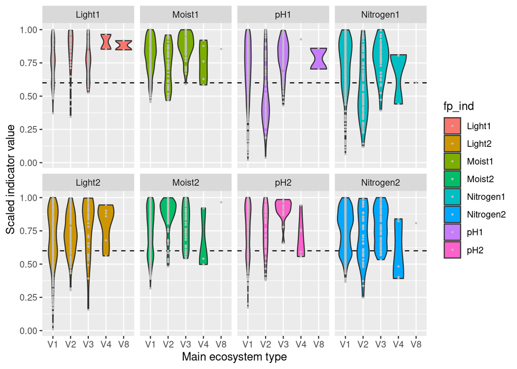

The functional signature from the plant communities in wetland ecosystems looks largely good, except for V2 (swamp forests), which show rather low index scores for the lower pH and Nitrogen indicators, i.e. suggesting too acidic conditions and too low nitrogen availability.

We can look at V2 specifically to see if this is the case for all sub-types.

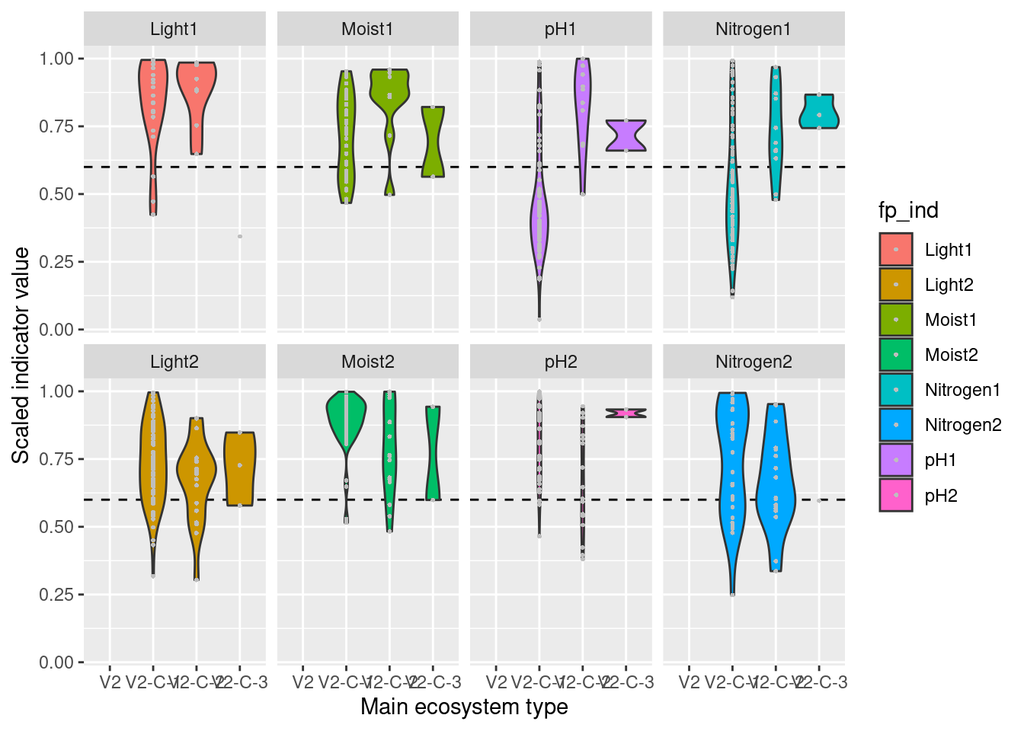

```r
# making the plot for V2 only
ggplot(res.wetland[res.wetland$hovedtype_rute=="V2",], aes(x=factor(kartleggingsenhet_1m2), y=scaled_value, fill=fp_ind)) +
  geom_hline(yintercept=0.6, linetype="dashed") +
  geom_violin() +
  #  geom_boxplot(width=0.2, color="grey") +
  geom_point(size=0.7, shape=16, color="grey") +
  facet_wrap(~factor(fp_ind,levels=c("Light1","Moist1","pH1","Nitrogen1","Light2","Moist2","pH2","Nitrogen2")), ncol = 4) +
  xlab("Main ecosystem type") +
  ylab("Scaled indicator value")
```

The deviations towards low pH and low nitrogen are mainly an issue for V2-C1, limestone-poor swamp forests.

### Indicator index maps

We can also show the results as a map, for instance for pH1 (the lower pH indicator), either by directly plotting the data onto the map…

```
## [1] "Nord-Norge"      "Midt-Norge"      "Ã\u0098stlandet" "Vestlandet"      "SÃ¸rlandet"
```

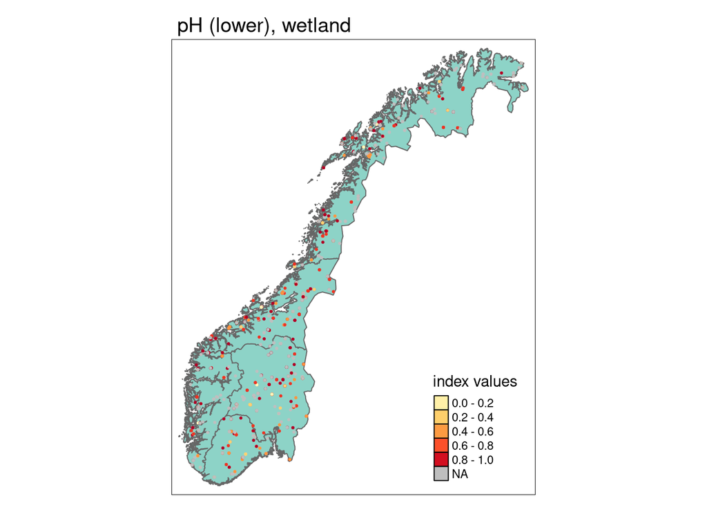

…but here the colors and values of the data points on the map are hard to make out.

### Regions - maps and statistics

Alternatively we can calculate and show the region-wise means and their related standard errors. But note that calculating a simple mean would be inappropriate for these data. This is because: (i) the scaled data are bound between 0 and 1, and thus follow a beta-distribution rather than a Gaussian one (ii) the ANO dataset has a nested structure

Therefore, we need to (i) use a beta-model, that (ii) can account for the nested structure of the data. Here, we apply the following function using either a glmmTMB null-model with a beta-distribution, logit link, and the nesting as a random intercept, or a simple betareg null-model with logit link if the nesting is not extensive enough for a mixed model.

```r
library(betareg)
library(glmmTMB)

expit <- function(L) exp(L) / (1+exp(L)) # since the beta-models use a logit link, we need to calculate the estimates back to the identity scale

# the function performs a glmmTMB if there's >= 5 random levels in the nesting structure
# if that is not the case, then the function performs a betareg if theres >= 2 observations
# if that is not the case either, then the function returns the value of the single observation with NA standard error

indmean.beta <- function(df) {

  st_geometry(df) <- NULL
  colnames(df) <- c("y","ran")

  if ( nrow(df[!is.na(df[,1]),]) >= 2 ) {

    if ( length(unique(df[!is.na(df[,1]),2])) >=5 ) {

      mod1 <- glmmTMB(y ~ 1 +(1|ran), family=beta_family(), data=df)

      return(c(
        expit(summary( mod1 )$coefficients$cond[1]),

        expit( summary( mod1 )$coefficients$cond[1] +
                 summary( mod1 )$coefficients$cond[2] )-
          expit( summary( mod1 )$coefficients$cond[1] ),

        nrow(df[!is.na(df$y),]),
        summary( mod1 )$coefficients$cond[1],
        summary( mod1 )$coefficients$cond[2]
      ))

    } else {

      mod2 <- betareg(y ~ 1, data=df)

      return(c(
        expit(summary( mod2 )$coefficients$mean[1]),
        expit( summary( mod2 )$coefficients$mean[1] +
                 summary( mod2 )$coefficients$mean[2] )-
          expit( summary( mod2 )$coefficients$mean[1] ),
        nrow(df[!is.na(df$y),]),
        summary( mod2 )$coefficients$mean[1],
        summary( mod2 )$coefficients$mean[2]
      ))

    }

  } else {

    return(c(df$y,NA,1,NA,NA))

  }

}
```

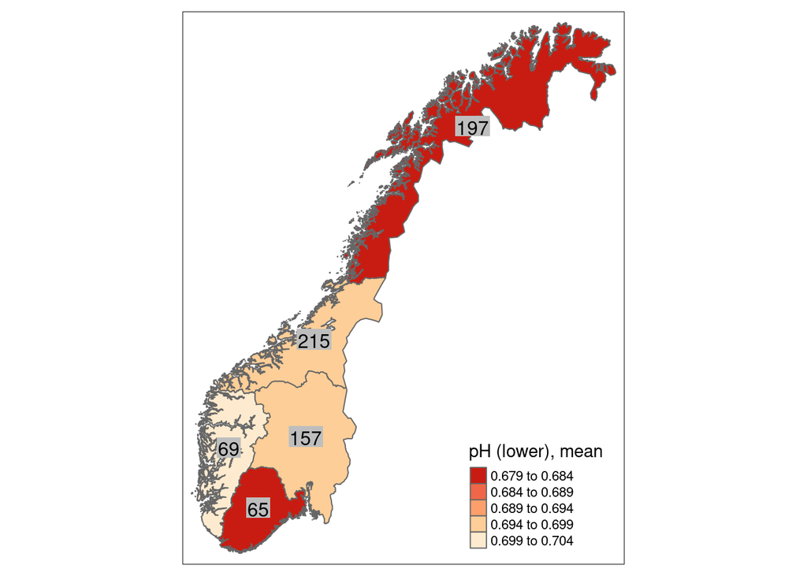

```r
res.wetland2 = st_join(res.wetland2, regnor, left = TRUE)

regnor <- regnor %>%
  mutate(
    pH1.reg.mean = c(indmean.beta(df=res.wetland2[res.wetland2$region=="Northern Norway",c("pH1","ano_flate_id")])[1],
                                 indmean.beta(df=res.wetland2[res.wetland2$region=="Central Norway",c("pH1","ano_flate_id")])[1],
                                 indmean.beta(df=res.wetland2[res.wetland2$region=="Eastern Norway",c("pH1","ano_flate_id")])[1],
                                 indmean.beta(df=res.wetland2[res.wetland2$region=="Western Norway",c("pH1","ano_flate_id")])[1],
                                 indmean.beta(df=res.wetland2[res.wetland2$region=="Southern Norway",c("pH1","ano_flate_id")])[1]
    ),
    pH1.reg.se = c(indmean.beta(df=res.wetland2[res.wetland2$region=="Northern Norway",c("pH1","ano_flate_id")])[2],
                               indmean.beta(df=res.wetland2[res.wetland2$region=="Central Norway",c("pH1","ano_flate_id")])[2],
                               indmean.beta(df=res.wetland2[res.wetland2$region=="Eastern Norway",c("pH1","ano_flate_id")])[2],
                               indmean.beta(df=res.wetland2[res.wetland2$region=="Western Norway",c("pH1","ano_flate_id")])[2],
                               indmean.beta(df=res.wetland2[res.wetland2$region=="Southern Norway",c("pH1","ano_flate_id")])[2]
    ),
    pH1.reg.n = c(nrow(res.wetland2[res.wetland2$region=="Northern Norway" & !is.na(res.wetland2$pH1),]),
                              nrow(res.wetland2[res.wetland2$region=="Central Norway" & !is.na(res.wetland2$pH1),]),
                              nrow(res.wetland2[res.wetland2$region=="Eastern Norway" & !is.na(res.wetland2$pH1),]),
                              nrow(res.wetland2[res.wetland2$region=="Western Norway" & !is.na(res.wetland2$pH1),]),
                              nrow(res.wetland2[res.wetland2$region=="Southern Norway" & !is.na(res.wetland2$pH1),])
    )
  )


## scaled value maps for pH1 (lower indicator)
# mean
tm_shape(regnor) +
  tm_polygons(col="pH1.reg.mean", title="pH (lower), mean", style="quantile", palette=rev(get_brewer_pal(palette="OrRd", n=5, plot=FALSE))) +
  tm_text("pH1.reg.n",col="black",bg.color="grey")
```

Mean index value by region for the lower pH indicator (i.e. index shows deviations towards a more acidic environment). Numbers in grey fields show the number of observations in the respective region.

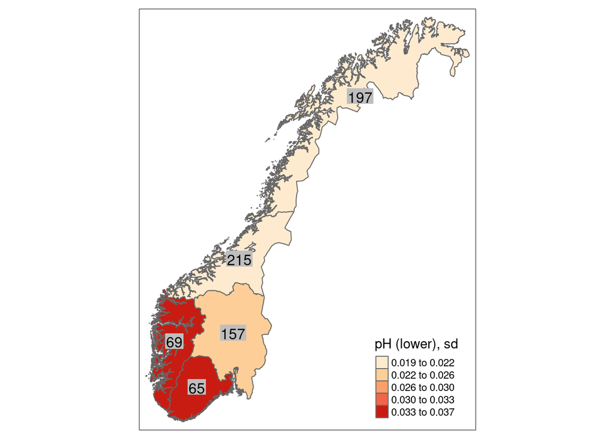

```r
# se
tm_shape(regnor) +
  tm_polygons(col="pH1.reg.se", title="pH (lower), sd", style="quantile", palette=get_brewer_pal(palette="OrRd", n=5, plot=FALSE)) +
  tm_text("pH1.reg.n",col="black",bg.color="grey")
```

Standard error to the mean index value by region for the lower pH indicator. Numbers in grey fields show the number of observations in the respective region.

### unscaled values vs. reference

We can also compare the unscaled values to the reference distribution in order to identify ecosystem types and functional plant indicators showing a deviation from the expectation. Since pH and nitrogen show some deviation of the lower pH indicator we exemplify this with these indicators for unscaled values.

```r
summary(res.wetland$kartleggingsenhet_1m2)
```

```
##      V1  V1-C-1  V1-C-2  V1-C-3  V1-C-4  V1-C-5  V1-C-6  V1-C-7  V1-C-8 V10-C-1 V10-C-3 V11-C-1
##       8    2144    1224     448     160    2424    1248     320      48      40       8      16
##     V12 V12-C-1 V12-C-2      V2  V2-C-1  V2-C-2  V2-C-3      V3  V3-C-1  V3-C-2      V4  V4-C-1
##      16     152       8       8     832     224      32      40     440     472       8      32
##  V4-C-2  V4-C-4  V6-C-1  V6-C-2  V6-C-3  V6-C-4  V6-C-5  V6-C-7  V6-C-9  V8-C-1  V8-C-2  V9-C-1
##      72       8      64       8      72      40       8       8       8      16       8      80
##  V9-C-2  V9-C-3
##      16      16
```

```r
length(unique(res.wetland$kartleggingsenhet_1m2))
```

```
## [1] 38
```

```r
# 16 NiN-types to plot
colnames(wetland.ref.cov[['Soil_reaction_pH']])
```

```
##  [1] "V3-C1a" "V3-C1b" "V3-C1c" "V3-C1d" "V3-C1e" "V1-C1a" "V1-C1b" "V1-C1c" "V1-C1d" "V1-C1e" "V1-C2a"
## [12] "V1-C2b" "V1-C2c" "V1-C2d" "V1-C3a" "V1-C3b" "V1-C3c" "V1-C3d" "V1-C4a" "V1-C4b" "V1-C4c" "V1-C4d"
## [23] "V1-C4e" "V1-C4f" "V1-C4g" "V1-C4h" "V3-C2"  "V1-C5"  "V1-C6a" "V1-C6b" "V1-C7a" "V1-C7b" "V1-C8a"
## [34] "V1-C8b" "V2-C1a" "V2-C1b" "V2-C2a" "V2-C2b" "V2-C3a" "V2-C3b" "V4-C2"  "V4-C3"  "V8-C1"  "V8-C2"
## [45] "V8-C3"
```

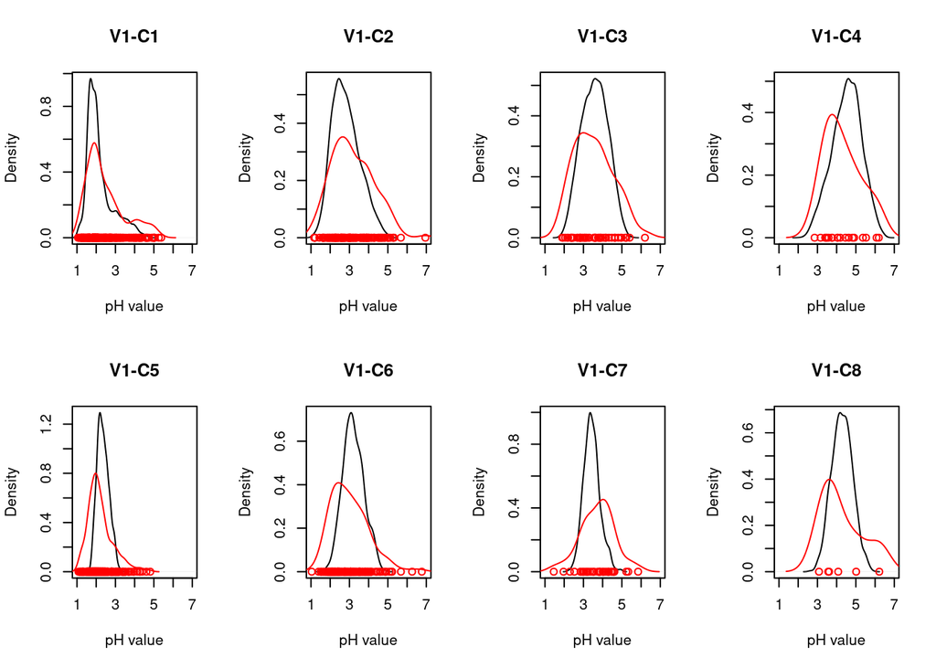

```r
### pH
par(mfrow=c(2,4))
## V1s
# V1-C-1
plot(density( as.matrix(wetland.ref.cov[['Soil_reaction_pH']][,c("V1-C1a","V1-C1b","V1-C1c","V1-C1d","V1-C1e")]) ,na.rm=T),
     xlim=c(1,7), type="l", main='V1-C1',xlab='pH value')
points(density(res.wetland[res.wetland$fp_ind=="pH1" & res.wetland$fp_ind=="pH1" & res.wetland$kartleggingsenhet_1m2=="V1-C-1",]$original,na.rm=T),
       type="l", col="red")
points(res.wetland[res.wetland$fp_ind=="pH1" & res.wetland$fp_ind=="pH1" & res.wetland$kartleggingsenhet_1m2=="V1-C-1",]$original,
       rep(0,length(res.wetland[res.wetland$fp_ind=="pH1" & res.wetland$fp_ind=="pH1" & res.wetland$kartleggingsenhet_1m2=="V1-C-1",]$original)),
       col="red")

# V1-C-2
plot(density( as.matrix(wetland.ref.cov[['Soil_reaction_pH']][,c("V1-C2a","V1-C2b","V1-C2c","V1-C2d")]) ,na.rm=T),
     xlim=c(1,7), type="l", main='V1-C2',xlab='pH value')
points(density(res.wetland[res.wetland$fp_ind=="pH1" & res.wetland$kartleggingsenhet_1m2=="V1-C-2",]$original,na.rm=T),
       type="l", col="red")
points(res.wetland[res.wetland$fp_ind=="pH1" & res.wetland$kartleggingsenhet_1m2=="V1-C-2",]$original,
       rep(0,length(res.wetland[res.wetland$fp_ind=="pH1" & res.wetland$kartleggingsenhet_1m2=="V1-C-2",]$original)),
       col="red")

# V1-C-3
plot(density( as.matrix(wetland.ref.cov[['Soil_reaction_pH']][,c("V1-C3a","V1-C3b","V1-C3c","V1-C3d")]) ,na.rm=T),
     xlim=c(1,7), type="l", main='V1-C3',xlab='pH value')
points(density(res.wetland[res.wetland$fp_ind=="pH1" & res.wetland$kartleggingsenhet_1m2=="V1-C-3",]$original,na.rm=T),
       type="l", col="red")
points(res.wetland[res.wetland$fp_ind=="pH1" & res.wetland$kartleggingsenhet_1m2=="V1-C-3",]$original,
       rep(0,length(res.wetland[res.wetland$fp_ind=="pH1" & res.wetland$kartleggingsenhet_1m2=="V1-C-3",]$original)),
       col="red")

# V1-C-4
plot(density( as.matrix(wetland.ref.cov[['Soil_reaction_pH']][,c("V1-C4a","V1-C4b","V1-C4c","V1-C4d","V1-C4e","V1-C4f","V1-C4g","V1-C4h")]) ,na.rm=T),
     xlim=c(1,7), type="l", main='V1-C4',xlab='pH value')
points(density(res.wetland[res.wetland$fp_ind=="pH1" & res.wetland$kartleggingsenhet_1m2=="V1-C-4",]$original,na.rm=T),
       type="l", col="red")
points(res.wetland[res.wetland$fp_ind=="pH1" & res.wetland$kartleggingsenhet_1m2=="V1-C-4",]$original,
       rep(0,length(res.wetland[res.wetland$fp_ind=="pH1" & res.wetland$kartleggingsenhet_1m2=="V1-C-4",]$original)),
       col="red")

# V1-C-5
plot(density( as.matrix(wetland.ref.cov[['Soil_reaction_pH']][,c("V1-C5")]) ,na.rm=T),
     xlim=c(1,7), type="l", main='V1-C5',xlab='pH value')
points(density(res.wetland[res.wetland$fp_ind=="pH1" & res.wetland$kartleggingsenhet_1m2=="V1-C-5",]$original,na.rm=T),
       type="l", col="red")
points(res.wetland[res.wetland$fp_ind=="pH1" & res.wetland$kartleggingsenhet_1m2=="V1-C-5",]$original,
       rep(0,length(res.wetland[res.wetland$fp_ind=="pH1" & res.wetland$kartleggingsenhet_1m2=="V1-C-5",]$original)),
       col="red")

# V1-C-6
plot(density( as.matrix(wetland.ref.cov[['Soil_reaction_pH']][,c("V1-C6a","V1-C6b")]) ,na.rm=T),
     xlim=c(1,7), type="l", main='V1-C6',xlab='pH value')
points(density(res.wetland[res.wetland$fp_ind=="pH1" & res.wetland$kartleggingsenhet_1m2=="V1-C-6",]$original,na.rm=T),
       type="l", col="red")
points(res.wetland[res.wetland$fp_ind=="pH1" & res.wetland$kartleggingsenhet_1m2=="V1-C-6",]$original,
       rep(0,length(res.wetland[res.wetland$fp_ind=="pH1" & res.wetland$kartleggingsenhet_1m2=="V1-C-6",]$original)),
       col="red")

# V1-C-7
plot(density( as.matrix(wetland.ref.cov[['Soil_reaction_pH']][,c("V1-C7a","V1-C7b")]) ,na.rm=T),
     xlim=c(1,7), type="l", main='V1-C7',xlab='pH value')
points(density(res.wetland[res.wetland$fp_ind=="pH1" & res.wetland$kartleggingsenhet_1m2=="V1-C-7",]$original,na.rm=T),
       type="l", col="red")
points(res.wetland[res.wetland$fp_ind=="pH1" & res.wetland$kartleggingsenhet_1m2=="V1-C-7",]$original,
       rep(0,length(res.wetland[res.wetland$fp_ind=="pH1" & res.wetland$kartleggingsenhet_1m2=="V1-C-7",]$original)),
       col="red")

# V1-C-8
plot(density( as.matrix(wetland.ref.cov[['Soil_reaction_pH']][,c("V1-C8a","V1-C8b")]) ,na.rm=T),
     xlim=c(1,7), type="l", main='V1-C8',xlab='pH value')
points(density(res.wetland[res.wetland$fp_ind=="pH1" & res.wetland$kartleggingsenhet_1m2=="V1-C-8",]$original,na.rm=T),
       type="l", col="red")
points(res.wetland[res.wetland$fp_ind=="pH1" & res.wetland$kartleggingsenhet_1m2=="V1-C-8",]$original,
       rep(0,length(res.wetland[res.wetland$fp_ind=="pH1" & res.wetland$kartleggingsenhet_1m2=="V1-C-8",]$original)),
       col="red")
```

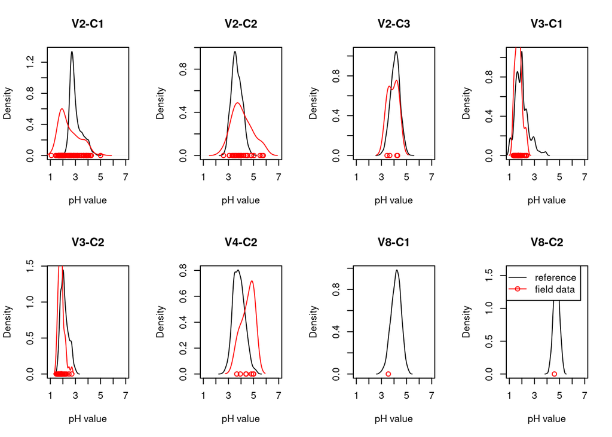

```r
par(mfrow=c(2,4))
## V2s
# V2-C-1
plot(density( as.matrix(wetland.ref.cov[['Soil_reaction_pH']][,c("V2-C1a","V2-C1b")]) ,na.rm=T),
     xlim=c(1,7), type="l", main='V2-C1',xlab='pH value')
points(density(res.wetland[res.wetland$fp_ind=="pH1" & res.wetland$fp_ind=="pH1" & res.wetland$kartleggingsenhet_1m2=="V2-C-1",]$original,na.rm=T),
       type="l", col="red")
points(res.wetland[res.wetland$fp_ind=="pH1" & res.wetland$fp_ind=="pH1" & res.wetland$kartleggingsenhet_1m2=="V2-C-1",]$original,
       rep(0,length(res.wetland[res.wetland$fp_ind=="pH1" & res.wetland$fp_ind=="pH1" & res.wetland$kartleggingsenhet_1m2=="V2-C-1",]$original)),
       col="red")

# V2-C-2
plot(density( as.matrix(wetland.ref.cov[['Soil_reaction_pH']][,c("V2-C2a","V2-C2b")]) ,na.rm=T),
     xlim=c(1,7), type="l", main='V2-C2',xlab='pH value')
points(density(res.wetland[res.wetland$fp_ind=="pH1" & res.wetland$fp_ind=="pH1" & res.wetland$kartleggingsenhet_1m2=="V2-C-2",]$original,na.rm=T),
       type="l", col="red")
points(res.wetland[res.wetland$fp_ind=="pH1" & res.wetland$fp_ind=="pH1" & res.wetland$kartleggingsenhet_1m2=="V2-C-2",]$original,
       rep(0,length(res.wetland[res.wetland$fp_ind=="pH1" & res.wetland$fp_ind=="pH1" & res.wetland$kartleggingsenhet_1m2=="V2-C-2",]$original)),
       col="red")

# V2-C-3
plot(density( as.matrix(wetland.ref.cov[['Soil_reaction_pH']][,c("V2-C3a","V2-C3b")]) ,na.rm=T),
     xlim=c(1,7), type="l", main='V2-C3',xlab='pH value')
points(density(res.wetland[res.wetland$fp_ind=="pH1" & res.wetland$fp_ind=="pH1" & res.wetland$kartleggingsenhet_1m2=="V2-C-3",]$original,na.rm=T),
       type="l", col="red")
points(res.wetland[res.wetland$fp_ind=="pH1" & res.wetland$fp_ind=="pH1" & res.wetland$kartleggingsenhet_1m2=="V2-C-3",]$original,
       rep(0,length(res.wetland[res.wetland$fp_ind=="pH1" & res.wetland$fp_ind=="pH1" & res.wetland$kartleggingsenhet_1m2=="V2-C-3",]$original)),
       col="red")

## V3s
# V3-C-1
plot(density( as.matrix(wetland.ref.cov[['Soil_reaction_pH']][,c("V3-C1a","V3-C1b","V3-C1c","V3-C1d","V3-C1e")]) ,na.rm=T),
     xlim=c(1,7), type="l", main='V3-C1',xlab='pH value')
points(density(res.wetland[res.wetland$fp_ind=="pH1" & res.wetland$fp_ind=="pH1" & res.wetland$kartleggingsenhet_1m2=="V3-C-1",]$original,na.rm=T),
       type="l", col="red")
points(res.wetland[res.wetland$fp_ind=="pH1" & res.wetland$fp_ind=="pH1" & res.wetland$kartleggingsenhet_1m2=="V3-C-1",]$original,
       rep(0,length(res.wetland[res.wetland$fp_ind=="pH1" & res.wetland$fp_ind=="pH1" & res.wetland$kartleggingsenhet_1m2=="V3-C-1",]$original)),
       col="red")

# V3-C-2
plot(density( as.matrix(wetland.ref.cov[['Soil_reaction_pH']][,c("V3-C2")]) ,na.rm=T),
     xlim=c(1,7), type="l", main='V3-C2',xlab='pH value')
points(density(res.wetland[res.wetland$fp_ind=="pH1" & res.wetland$fp_ind=="pH1" & res.wetland$kartleggingsenhet_1m2=="V3-C-2",]$original,na.rm=T),
       type="l", col="red")
points(res.wetland[res.wetland$fp_ind=="pH1" & res.wetland$fp_ind=="pH1" & res.wetland$kartleggingsenhet_1m2=="V3-C-2",]$original,
       rep(0,length(res.wetland[res.wetland$fp_ind=="pH1" & res.wetland$fp_ind=="pH1" & res.wetland$kartleggingsenhet_1m2=="V3-C-2",]$original)),
       col="red")

## V4s
# V4-C-2
plot(density( as.matrix(wetland.ref.cov[['Soil_reaction_pH']][,c("V4-C2")]) ,na.rm=T),
     xlim=c(1,7), type="l", main='V4-C2',xlab='pH value')
points(density(res.wetland[res.wetland$fp_ind=="pH1" & res.wetland$fp_ind=="pH1" & res.wetland$kartleggingsenhet_1m2=="V4-C-2",]$original,na.rm=T),
       type="l", col="red")
points(res.wetland[res.wetland$fp_ind=="pH1" & res.wetland$fp_ind=="pH1" & res.wetland$kartleggingsenhet_1m2=="V4-C-2",]$original,
       rep(0,length(res.wetland[res.wetland$fp_ind=="pH1" & res.wetland$fp_ind=="pH1" & res.wetland$kartleggingsenhet_1m2=="V4-C-2",]$original)),
       col="red")


## V8s
# V8-C-1
plot(density( as.matrix(wetland.ref.cov[['Soil_reaction_pH']][,c("V8-C1")]) ,na.rm=T),
     xlim=c(1,7), type="l", main='V8-C1',xlab='pH value')
#points(density(res.wetland[res.wetland$fp_ind=="pH1" & res.wetland$fp_ind=="pH1" & res.wetland$kartleggingsenhet_1m2=="V8-C-1",]$original,na.rm=T),
#       type="l", col="red")
points(res.wetland[res.wetland$fp_ind=="pH1" & res.wetland$fp_ind=="pH1" & res.wetland$kartleggingsenhet_1m2=="V8-C-1",]$original,
       rep(0,length(res.wetland[res.wetland$fp_ind=="pH1" & res.wetland$fp_ind=="pH1" & res.wetland$kartleggingsenhet_1m2=="V8-C-1",]$original)),
       col="red")

# V8-C-2
plot(density( as.matrix(wetland.ref.cov[['Soil_reaction_pH']][,c("V8-C2")]) ,na.rm=T),
     xlim=c(1,7), type="l", main='V8-C2',xlab='pH value')
#points(density(res.wetland[res.wetland$fp_ind=="pH1" & res.wetland$fp_ind=="pH1" & res.wetland$kartleggingsenhet_1m2=="V8-C-2",]$original,na.rm=T),
#       type="l", col="red")
points(res.wetland[res.wetland$fp_ind=="pH1" & res.wetland$fp_ind=="pH1" & res.wetland$kartleggingsenhet_1m2=="V8-C-2",]$original,
       rep(0,length(res.wetland[res.wetland$fp_ind=="pH1" & res.wetland$fp_ind=="pH1" & res.wetland$kartleggingsenhet_1m2=="V8-C-2",]$original)),
       col="red")
legend("topleft", legend=c("reference","field data"), pch=c(NA,1), lty=1, col=c("black","red"))
```

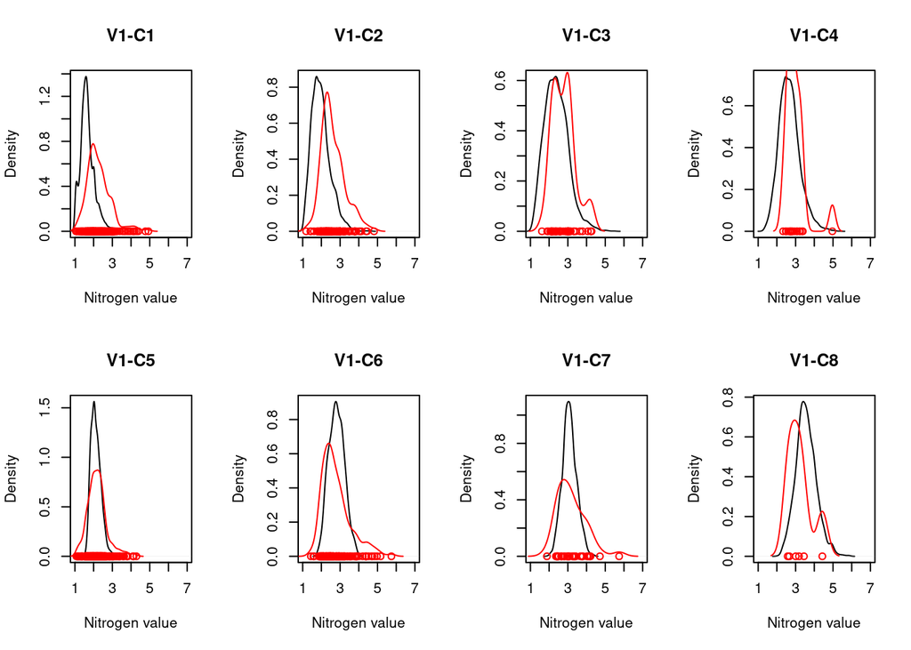

```r
### Nitrogen
par(mfrow=c(2,4))
## V1s
# V1-C-1
plot(density( as.matrix(wetland.ref.cov[['Nitrogen']][,c("V1-C1a","V1-C1b","V1-C1c","V1-C1d","V1-C1e")]) ,na.rm=T),
     xlim=c(1,7), type="l", main='V1-C1',xlab='Nitrogen value')
points(density(res.wetland[res.wetland$fp_ind=="Nitrogen1" & res.wetland$fp_ind=="Nitrogen1" & res.wetland$kartleggingsenhet_1m2=="V1-C-1",]$original,na.rm=T),
       type="l", col="red")
points(res.wetland[res.wetland$fp_ind=="Nitrogen1" & res.wetland$fp_ind=="Nitrogen1" & res.wetland$kartleggingsenhet_1m2=="V1-C-1",]$original,
       rep(0,length(res.wetland[res.wetland$fp_ind=="Nitrogen1" & res.wetland$fp_ind=="Nitrogen1" & res.wetland$kartleggingsenhet_1m2=="V1-C-1",]$original)),
       col="red")

# V1-C-2
plot(density( as.matrix(wetland.ref.cov[['Nitrogen']][,c("V1-C2a","V1-C2b","V1-C2c","V1-C2d")]) ,na.rm=T),
     xlim=c(1,7), type="l", main='V1-C2',xlab='Nitrogen value')
points(density(res.wetland[res.wetland$fp_ind=="Nitrogen1" & res.wetland$kartleggingsenhet_1m2=="V1-C-2",]$original,na.rm=T),
       type="l", col="red")
points(res.wetland[res.wetland$fp_ind=="Nitrogen1" & res.wetland$kartleggingsenhet_1m2=="V1-C-2",]$original,
       rep(0,length(res.wetland[res.wetland$fp_ind=="Nitrogen1" & res.wetland$kartleggingsenhet_1m2=="V1-C-2",]$original)),
       col="red")

# V1-C-3
plot(density( as.matrix(wetland.ref.cov[['Nitrogen']][,c("V1-C3a","V1-C3b","V1-C3c","V1-C3d")]) ,na.rm=T),
     xlim=c(1,7), type="l", main='V1-C3',xlab='Nitrogen value')
points(density(res.wetland[res.wetland$fp_ind=="Nitrogen1" & res.wetland$kartleggingsenhet_1m2=="V1-C-3",]$original,na.rm=T),
       type="l", col="red")
points(res.wetland[res.wetland$fp_ind=="Nitrogen1" & res.wetland$kartleggingsenhet_1m2=="V1-C-3",]$original,
       rep(0,length(res.wetland[res.wetland$fp_ind=="Nitrogen1" & res.wetland$kartleggingsenhet_1m2=="V1-C-3",]$original)),
       col="red")

# V1-C-4
plot(density( as.matrix(wetland.ref.cov[['Nitrogen']][,c("V1-C4a","V1-C4b","V1-C4c","V1-C4d","V1-C4e","V1-C4f","V1-C4g","V1-C4h")]) ,na.rm=T),
     xlim=c(1,7), type="l", main='V1-C4',xlab='Nitrogen value')
points(density(res.wetland[res.wetland$fp_ind=="Nitrogen1" & res.wetland$kartleggingsenhet_1m2=="V1-C-4",]$original,na.rm=T),
       type="l", col="red")
points(res.wetland[res.wetland$fp_ind=="Nitrogen1" & res.wetland$kartleggingsenhet_1m2=="V1-C-4",]$original,
       rep(0,length(res.wetland[res.wetland$fp_ind=="Nitrogen1" & res.wetland$kartleggingsenhet_1m2=="V1-C-4",]$original)),
       col="red")

# V1-C-5
plot(density( as.matrix(wetland.ref.cov[['Nitrogen']][,c("V1-C5")]) ,na.rm=T),
     xlim=c(1,7), type="l", main='V1-C5',xlab='Nitrogen value')
points(density(res.wetland[res.wetland$fp_ind=="Nitrogen1" & res.wetland$kartleggingsenhet_1m2=="V1-C-5",]$original,na.rm=T),
       type="l", col="red")
points(res.wetland[res.wetland$fp_ind=="Nitrogen1" & res.wetland$kartleggingsenhet_1m2=="V1-C-5",]$original,
       rep(0,length(res.wetland[res.wetland$fp_ind=="Nitrogen1" & res.wetland$kartleggingsenhet_1m2=="V1-C-5",]$original)),
       col="red")

# V1-C-6
plot(density( as.matrix(wetland.ref.cov[['Nitrogen']][,c("V1-C6a","V1-C6b")]) ,na.rm=T),
     xlim=c(1,7), type="l", main='V1-C6',xlab='Nitrogen value')
points(density(res.wetland[res.wetland$fp_ind=="Nitrogen1" & res.wetland$kartleggingsenhet_1m2=="V1-C-6",]$original,na.rm=T),
       type="l", col="red")
points(res.wetland[res.wetland$fp_ind=="Nitrogen1" & res.wetland$kartleggingsenhet_1m2=="V1-C-6",]$original,
       rep(0,length(res.wetland[res.wetland$fp_ind=="Nitrogen1" & res.wetland$kartleggingsenhet_1m2=="V1-C-6",]$original)),
       col="red")

# V1-C-7
plot(density( as.matrix(wetland.ref.cov[['Nitrogen']][,c("V1-C7a","V1-C7b")]) ,na.rm=T),
     xlim=c(1,7), type="l", main='V1-C7',xlab='Nitrogen value')
points(density(res.wetland[res.wetland$fp_ind=="Nitrogen1" & res.wetland$kartleggingsenhet_1m2=="V1-C-7",]$original,na.rm=T),
       type="l", col="red")
points(res.wetland[res.wetland$fp_ind=="Nitrogen1" & res.wetland$kartleggingsenhet_1m2=="V1-C-7",]$original,
       rep(0,length(res.wetland[res.wetland$fp_ind=="Nitrogen1" & res.wetland$kartleggingsenhet_1m2=="V1-C-7",]$original)),
       col="red")

# V1-C-8
plot(density( as.matrix(wetland.ref.cov[['Nitrogen']][,c("V1-C8a","V1-C8b")]) ,na.rm=T),
     xlim=c(1,7), type="l", main='V1-C8',xlab='Nitrogen value')
points(density(res.wetland[res.wetland$fp_ind=="Nitrogen1" & res.wetland$kartleggingsenhet_1m2=="V1-C-8",]$original,na.rm=T),
       type="l", col="red")
points(res.wetland[res.wetland$fp_ind=="Nitrogen1" & res.wetland$kartleggingsenhet_1m2=="V1-C-8",]$original,
       rep(0,length(res.wetland[res.wetland$fp_ind=="Nitrogen1" & res.wetland$kartleggingsenhet_1m2=="V1-C-8",]$original)),
       col="red")
```

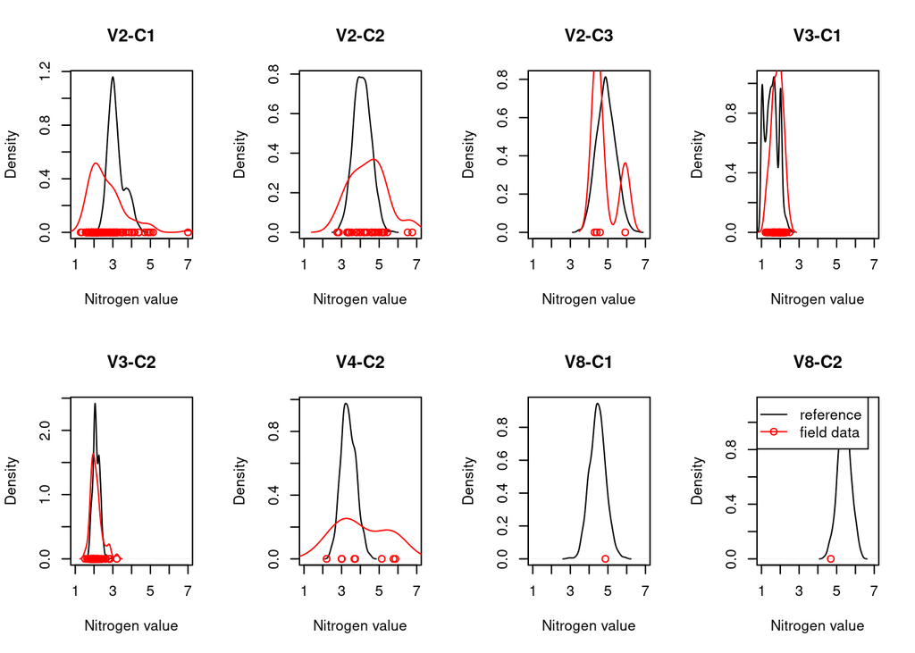

```r
par(mfrow=c(2,4))
## V2s
# V2-C-1
plot(density( as.matrix(wetland.ref.cov[['Nitrogen']][,c("V2-C1a","V2-C1b")]) ,na.rm=T),
     xlim=c(1,7), type="l", main='V2-C1',xlab='Nitrogen value')
points(density(res.wetland[res.wetland$fp_ind=="Nitrogen1" & res.wetland$fp_ind=="Nitrogen1" & res.wetland$kartleggingsenhet_1m2=="V2-C-1",]$original,na.rm=T),
       type="l", col="red")
points(res.wetland[res.wetland$fp_ind=="Nitrogen1" & res.wetland$fp_ind=="Nitrogen1" & res.wetland$kartleggingsenhet_1m2=="V2-C-1",]$original,
       rep(0,length(res.wetland[res.wetland$fp_ind=="Nitrogen1" & res.wetland$fp_ind=="Nitrogen1" & res.wetland$kartleggingsenhet_1m2=="V2-C-1",]$original)),
       col="red")

# V2-C-2
plot(density( as.matrix(wetland.ref.cov[['Nitrogen']][,c("V2-C2a","V2-C2b")]) ,na.rm=T),
     xlim=c(1,7), type="l", main='V2-C2',xlab='Nitrogen value')
points(density(res.wetland[res.wetland$fp_ind=="Nitrogen1" & res.wetland$fp_ind=="Nitrogen1" & res.wetland$kartleggingsenhet_1m2=="V2-C-2",]$original,na.rm=T),
       type="l", col="red")
points(res.wetland[res.wetland$fp_ind=="Nitrogen1" & res.wetland$fp_ind=="Nitrogen1" & res.wetland$kartleggingsenhet_1m2=="V2-C-2",]$original,
       rep(0,length(res.wetland[res.wetland$fp_ind=="Nitrogen1" & res.wetland$fp_ind=="Nitrogen1" & res.wetland$kartleggingsenhet_1m2=="V2-C-2",]$original)),
       col="red")

# V2-C-3
plot(density( as.matrix(wetland.ref.cov[['Nitrogen']][,c("V2-C3a","V2-C3b")]) ,na.rm=T),
     xlim=c(1,7), type="l", main='V2-C3',xlab='Nitrogen value')
points(density(res.wetland[res.wetland$fp_ind=="Nitrogen1" & res.wetland$fp_ind=="Nitrogen1" & res.wetland$kartleggingsenhet_1m2=="V2-C-3",]$original,na.rm=T),
       type="l", col="red")
points(res.wetland[res.wetland$fp_ind=="Nitrogen1" & res.wetland$fp_ind=="Nitrogen1" & res.wetland$kartleggingsenhet_1m2=="V2-C-3",]$original,
       rep(0,length(res.wetland[res.wetland$fp_ind=="Nitrogen1" & res.wetland$fp_ind=="Nitrogen1" & res.wetland$kartleggingsenhet_1m2=="V2-C-3",]$original)),
       col="red")

## V3s
# V3-C-1
plot(density( as.matrix(wetland.ref.cov[['Nitrogen']][,c("V3-C1a","V3-C1b","V3-C1c","V3-C1d","V3-C1e")]) ,na.rm=T),
     xlim=c(1,7), type="l", main='V3-C1',xlab='Nitrogen value')
points(density(res.wetland[res.wetland$fp_ind=="Nitrogen1" & res.wetland$fp_ind=="Nitrogen1" & res.wetland$kartleggingsenhet_1m2=="V3-C-1",]$original,na.rm=T),
       type="l", col="red")
points(res.wetland[res.wetland$fp_ind=="Nitrogen1" & res.wetland$fp_ind=="Nitrogen1" & res.wetland$kartleggingsenhet_1m2=="V3-C-1",]$original,
       rep(0,length(res.wetland[res.wetland$fp_ind=="Nitrogen1" & res.wetland$fp_ind=="Nitrogen1" & res.wetland$kartleggingsenhet_1m2=="V3-C-1",]$original)),
       col="red")

# V3-C-2
plot(density( as.matrix(wetland.ref.cov[['Nitrogen']][,c("V3-C2")]) ,na.rm=T),
     xlim=c(1,7), type="l", main='V3-C2',xlab='Nitrogen value')
points(density(res.wetland[res.wetland$fp_ind=="Nitrogen1" & res.wetland$fp_ind=="Nitrogen1" & res.wetland$kartleggingsenhet_1m2=="V3-C-2",]$original,na.rm=T),
       type="l", col="red")
points(res.wetland[res.wetland$fp_ind=="Nitrogen1" & res.wetland$fp_ind=="Nitrogen1" & res.wetland$kartleggingsenhet_1m2=="V3-C-2",]$original,
       rep(0,length(res.wetland[res.wetland$fp_ind=="Nitrogen1" & res.wetland$fp_ind=="Nitrogen1" & res.wetland$kartleggingsenhet_1m2=="V3-C-2",]$original)),
       col="red")

## V4s
# V4-C-2
plot(density( as.matrix(wetland.ref.cov[['Nitrogen']][,c("V4-C2")]) ,na.rm=T),
     xlim=c(1,7), type="l", main='V4-C2',xlab='Nitrogen value')
points(density(res.wetland[res.wetland$fp_ind=="Nitrogen1" & res.wetland$fp_ind=="Nitrogen1" & res.wetland$kartleggingsenhet_1m2=="V4-C-2",]$original,na.rm=T),
       type="l", col="red")
points(res.wetland[res.wetland$fp_ind=="Nitrogen1" & res.wetland$fp_ind=="Nitrogen1" & res.wetland$kartleggingsenhet_1m2=="V4-C-2",]$original,
       rep(0,length(res.wetland[res.wetland$fp_ind=="Nitrogen1" & res.wetland$fp_ind=="Nitrogen1" & res.wetland$kartleggingsenhet_1m2=="V4-C-2",]$original)),
       col="red")

## V8s
# V8-C-1
plot(density( as.matrix(wetland.ref.cov[['Nitrogen']][,c("V8-C1")]) ,na.rm=T),
     xlim=c(1,7), type="l", main='V8-C1',xlab='Nitrogen value')
#points(density(res.wetland[res.wetland$fp_ind=="Nitrogen1" & res.wetland$fp_ind=="Nitrogen1" & res.wetland$kartleggingsenhet_1m2=="V8-C-1",]$original,na.rm=T),
#       type="l", col="red")
points(res.wetland[res.wetland$fp_ind=="Nitrogen1" & res.wetland$fp_ind=="Nitrogen1" & res.wetland$kartleggingsenhet_1m2=="V8-C-1",]$original,
       rep(0,length(res.wetland[res.wetland$fp_ind=="Nitrogen1" & res.wetland$fp_ind=="Nitrogen1" & res.wetland$kartleggingsenhet_1m2=="V8-C-1",]$original)),
       col="red")

# V8-C-2
plot(density( as.matrix(wetland.ref.cov[['Nitrogen']][,c("V8-C2")]) ,na.rm=T),
     xlim=c(1,7), type="l", main='V8-C2',xlab='Nitrogen value')
#points(density(res.wetland[res.wetland$fp_ind=="Nitrogen1" & res.wetland$fp_ind=="Nitrogen1" & res.wetland$kartleggingsenhet_1m2=="V8-C-2",]$original,na.rm=T),
#       type="l", col="red")
points(res.wetland[res.wetland$fp_ind=="Nitrogen1" & res.wetland$fp_ind=="Nitrogen1" & res.wetland$kartleggingsenhet_1m2=="V8-C-2",]$original,
       rep(0,length(res.wetland[res.wetland$fp_ind=="Nitrogen1" & res.wetland$fp_ind=="Nitrogen1" & res.wetland$kartleggingsenhet_1m2=="V8-C-2",]$original)),
       col="red")

legend("topleft", legend=c("reference","field data"), pch=c(NA,1), lty=1, col=c("black","red"))
```

THe figure shows that deviations mainly occur in V2-C1, which represents limestone-poor swamp forests. According to the functional signature from the plant community composition many of the occurrences of this ecosystem type are too acidic and may have too low availability of nitrogen.

### Eksport file (final product)